# SUMMATIVE ASSESSMENT 1 (STATISTICS AND PROBABILITY)

JOHN CARLOS QUINTERO & DWIGHT JIRO GONZALES

2024-03-19

## 1. calculate the probability that a randomly selected product is defective

```r
calc_defective_prob <- function(x1, x2, x3, y1, y2, y3) {
  if (is.na(x1) || is.na(x2) || is.na(x3) || is.na(y1) || is.na(y2) || is.na(y3)) {
    print("Please enter numeric values!")
    return(NULL)
  }

  if (!(0.1 <= x1 && x1 <= 0.4 && 0.1 <= x2 && x2 <= 0.4 && 0.1 <= x3 && x3 <= 0.4)) {
    print("Please input values between 0.1 to 0.4!")
    return(NULL)
  }

  if (!(0.01 <= y1 && y1 <= 0.05 && 0.01 <= y2 && y2 <= 0.05 && 0.01 <= y3 && y3 <= 0.05)) {
    print("Please input values between 0.01 to 0.05!")
    return(NULL)
  }

  total_defective_products <- x1 * y1 + x2 * y2 + x3 * y3
  total_products <- x1 + x2 + x3
  prob_defective_prod <- total_defective_products / total_products

  return(prob_defective_prod)
}

x1 <- 0.3
x2 <- 0.2
x3 <- 0.1
y1 <- 0.03
y2 <- 0.04
y3 <- 0.02

#x1 <- as.numeric(readline(prompt = "Enter x1 (0.1 to 0.4): "))
#x2 <- as.numeric(readline(prompt = "Enter x2 (0.1 to 0.4): "))
#x3 <- as.numeric(readline(prompt = "Enter x3 (0.1 to 0.4): "))
#y1 <- as.numeric(readline(prompt = "Enter y1 (0.01 to 0.05): "))
#y2 <- as.numeric(readline(prompt = "Enter y2 (0.01 to 0.05): "))
#y3 <- as.numeric(readline(prompt = "Enter y3 (0.01 to 0.05): "))


prob <- calc_defective_prob(x1, x2, x3, y1, y2, y3)

if (!is.null(prob)) {
  print(sprintf("The probability that a randomly selected product is defective is: %.2f%%", prob * 100))
}
```

```
## [1] "The probability that a randomly selected product is defective is: 3.17%"
```

## 2.) With your own computing experience, develop a front end to R that allows the user

to input the values of a univariate discrete random variable and the associated probabilities and to obtain the mean and variance, and

to input the values of a bivariate discrete random variable and the associated probabilities and to obtain the marginal and conditional distributions.

Your program should provide a facility to calculate the mean and variance of each distribution, and to plot the pdf and cdf. In each program, do validity checks that the probabilities are in the interval [0, 1], and that they sum to one.

```r
library(shiny)
```

```r
library(ggplot2)
ui <- fluidPage(
  titlePanel("Random Variable Analyzer"),

  sidebarLayout(
    sidebarPanel(
      radioButtons("variable_type", "Select Variable Type:",
                   choices = c("Univariate", "Bivariate")),
      conditionalPanel(
        condition = "input.variable_type == 'Univariate'",
        textInput("values", "Values (comma-separated):"),
        textInput("probabilities", "Probabilities (comma-separated):")
      ),
      conditionalPanel(
        condition = "input.variable_type == 'Bivariate'",
        textInput("values_x", "Values of X (comma-separated):"),
        textInput("values_y", "Values of Y (comma-separated):"),
        textInput("probabilities", "Joint Probabilities (comma-separated):")
      ),
      actionButton("calculate", "Calculate"),
      br(),
      h4("Results:"),
      verbatimTextOutput("results")
    ),
    mainPanel(
      plotOutput("pdf_plot"),
      plotOutput("cdf_plot")
    )
  )
)

server <- function(input, output) {
  observeEvent(input$calculate, {
    # Convert input values to numeric vectors
    if (input$variable_type == "Univariate") {
      values <- as.numeric(unlist(strsplit(input$values, ",")))
    } else {
      values_x <- as.numeric(unlist(strsplit(input$values_x, ",")))
      values_y <- as.numeric(unlist(strsplit(input$values_y, ",")))
    }
    probabilities <- as.numeric(unlist(strsplit(input$probabilities, ",")))

    # Check validity of probabilities
    if (any(probabilities < 0) || any(probabilities > 1) || sum(probabilities) != 1) {
      output$results <- renderText("Invalid probabilities!")
      return(NULL)
    }

    mean_value <- sum(values * probabilities)
    variance <- sum((values - mean_value)^2 * probabilities)

    df <- data.frame(x = values, p = probabilities)
    df <- df[order(df$x), ]
    df$cdf <- cumsum(df$p)

    output$pdf_plot <- renderPlot({
      ggplot(df, aes(x, p)) + geom_bar(stat = "identity", fill = "skyblue") +
        labs(title = "Probability Density Function", x = "Value", y = "Probability")
    })

    output$cdf_plot <- renderPlot({
      ggplot(df, aes(x, cdf)) + geom_step(color = "blue") +
        labs(title = "Cumulative Distribution Function", x = "Value", y = "Cumulative Probability")
    })

    output$results <- renderPrint({
      paste("Mean:", mean_value, "\nVariance:", variance)
    })
  })
}

shinyApp(ui = ui, server = server)
```

Shiny applications not supported in static R Markdown documents

## 3.) By generating 10,000 searches in R, carry out a simulation experiment for a search engine going through a list of sites for a given key phrase, until the key phrase is found. You should allow your program to input the probability p that any site will contain the key phrase.

Plot the simulated pdf and calculate its mean and variance, and

Obtain the simulated conditional distribution of searches when three searches have been carried out without success. Calculate its mean and variance, and satisfy yourself that they are equivalent to the simulated distribution of the complete set.

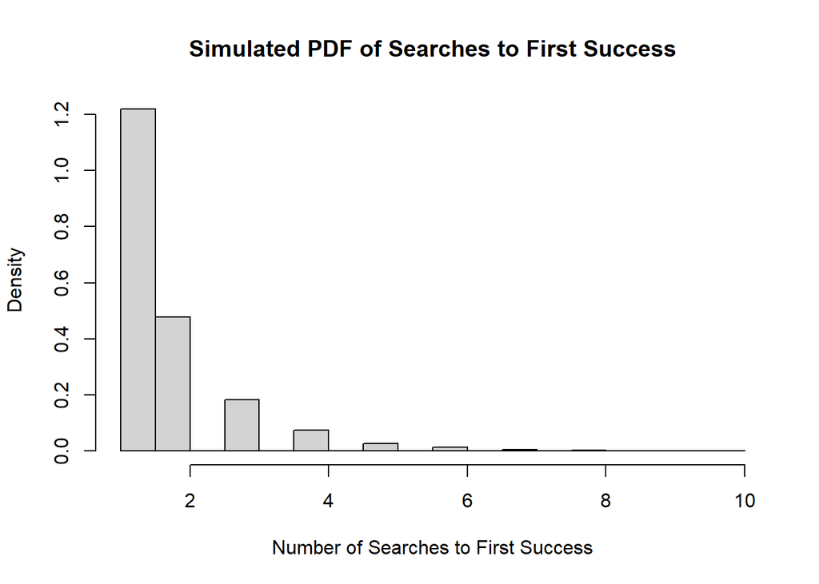

```r
search_simulation <- function(number_searches, p) {
  searches_success <- numeric(number_searches)
  for (i in 1:number_searches) {
    searches <- 0
    while (runif(1) > p) {
      searches <- searches + 1
    }
    searches_success[i] <- searches + 1
  }
  return(searches_success)
}

number_searches <- 10000
p <- 0.6

searches_success <- search_simulation(number_searches, p)  # Corrected num_searches to number_searches
hist(searches_success, breaks = 30, prob = TRUE, main = "Simulated PDF of Searches to First Success", xlab = "Number of Searches to First Success")
```

```r
mean_searches <- mean(searches_success)
variance_searchers <- var(searches_success)
cat("Mean of Searches to First Success:", mean_searches, "\n")
```

```
## Mean of Searches to First Success: 1.647
```

```r
cat("Variance of Searches to First Success:", variance_searchers, "\n")
```

```
## Variance of Searches to First Success: 1.0931
```

```r
conditional_distribution <- searches_success[searches_success > 3]  # Corrected searches_to_success to searches_success
mean_conditional <- mean(conditional_distribution)
variance_conditional <- var(conditional_distribution)
cat("Mean of Conditional Distribution (X > 3):", mean_conditional, "\n")
```

```
## Mean of Conditional Distribution (X > 3): 4.700491
```

```r
cat("Variance of Conditional Distribution (X > 3):", variance_conditional, "\n")
```

```
## Variance of Conditional Distribution (X > 3): 1.170803
```

```r
prob_1 <- mean(searches_success == 1)
prob_4_given_3 <- mean(searches_success == 4 & searches_success > 3)
prob_2_given_3 <- mean(searches_success == 2 & searches_success > 3)

cat("a) P(X = 4 | X > 3):", prob_4_given_3, "\n")
```

```
## a) P(X = 4 | X > 3): 0.0366
```

```r
cat("   P(X = 1):", prob_1, "\n")
```

```
##    P(X = 1): 0.6093
```

```r
cat("b) P(X = 2 | X > 3):", prob_2_given_3, "\n")
```

```
## b) P(X = 2 | X > 3): 0
```

```r
cat("   P(X = 2):", mean(searches_success == 2), "\n")
```

```
##    P(X = 2): 0.2383
```